# sobol

2022-04-26

# Sobol in R

- *Sensitivity* package
- Sobol Indices require estimation - and there are different methods to do that
- The *Sensitivity* package has several of those
- today we will use *sobolSalt* - which uses a method by Saltelli (who has written extensively on Sensitivity analysis)
- R help pages for *Sensitivity* provide many good references
- This is a nice overview paper

[Variance Based Methods](https://www.sciencedirect.com/science/article/pii/S0010465509003087?casa_token=xG4MJV4hwJgAAAAA:Tq_CLHTqtM1wDvhzviZFgm6sVBdOoYzQdFfOGplEi5OUxLSWxaKITce-CzxLxfS6993rNnbK1Q)

# Sobol - how to

Similar workflow to LHS

- run Sobol to get parameter sets in a sensitivity analysis object
- run model with those parameter sets
- tell the senstivity object about results associated with each parameter set
- look at sensitivity analysis metric from Sobol

Generation of parameter sets slightly different

- generate two samples of parameter sets by samplng from apriori (expected) distributions
- these would be the distributions you used for LHS

# Example

Atmospheric Conductance as a function of windspeed, vegetation height and parameters

```r
source("../R/Catm.R")

# generate two examples of random number from parameter distributions

np=1000
k_o = rnorm(mean=0.1,sd=0.1*0.1, n=np)
k_d = rnorm(mean=0.7, sd=0.7*0.1, n=np)
v = rnorm(mean=250, sd=30, n=np)
height = runif(min=9.5, max=10.5, n=np)

X1 = cbind.data.frame(k_o, k_d, v, height=height)

# repeat sampling
k_o = rnorm(mean=0.1,sd=0.1*0.1, n=np)
k_d = rnorm(mean=0.7, sd=0.7*0.1, n=np)
v = rnorm(mean=250, sd=30, n=np)
height = runif(min=9.5, max=10.5, n=np)

X2 = cbind.data.frame(k_o, k_d, v, height=height)

# there are different versions of sobol functions that have different approaches for estimating parameters and indices, we use an approach implemented by jansen

sens_Catm_Sobol = sobolSalt(model = NULL, X1, X2, nboot = 100)


# Take a look at the Sobol generated sensitivity object
# your parameters sets for sensitivity analysis are in X
```

# Sobol Indices

now run model for Sobol generated parameter sets and compute indices

- pay attention to values of the indices and confidence intervals
  - if 0 is within the confidence interval, parameter uncertainty is not influencing output
- substantial differences between total effect and first order indices suggest parameter interactions

TIP: a useful plotting strategy is to plot model output against parameter with the highest total effect and then use the parameter with second highest total effect for color

```r
# run model for all parameter sets
# make sure you give the parameters names

parms = as.data.frame(sens_Catm_Sobol$X)
colnames(parms)= colnames(X1)
res = pmap_dbl(parms, Catm)


sens_Catm_Sobol = sensitivity::tell(sens_Catm_Sobol,res, res.names="ga")

# main effect:  partitions variance (main effect without co-variance) - sums approximately to one
sens_Catm_Sobol$S
```

```
##     original         bias std. error   min. c.i.  max. c.i.
## X1 0.2278199 0.0010046197 0.02798490  0.17849942 0.28706229
## X2 0.5453622 0.0001862649 0.02620336  0.49398174 0.61526142
## X3 0.2062356 0.0049731943 0.03249277  0.13738073 0.26554774
## X4 0.0108499 0.0049762525 0.03076644 -0.05428803 0.07697736
```

```r
# useful to add names
row.names(sens_Catm_Sobol$S) = colnames(parms)
sens_Catm_Sobol$S
```

[output not shown]

```r
# total effect - accounts for parameter interactions
row.names(sens_Catm_Sobol$T) = colnames(parms)
sens_Catm_Sobol$T
```

```
##           original          bias   std. error   min. c.i.   max. c.i.
## k_o    0.258903807  7.948184e-04 0.0156188703 0.225431112 0.294229250
## k_d    0.591553723 -3.541859e-03 0.0277432231 0.543434433 0.657131900
## height 0.004599674  4.127599e-05 0.0004570929 0.003645662 0.005510348
```

```r
# Both the main effect and total effect can tell us something about how the parameter influences results


print(sens_Catm_Sobol)
```

```
##
## Call:
## sobolSalt(model = NULL, X1 = X1, X2 = X2, nboot = 100)
##
## Model runs: 6000
##
## Model variance: 22876360
##
## First order indices:
##         original         bias std. error   min. c.i.  max. c.i.
## k_o    0.2278199 0.0010046197 0.02798490  0.17849942 0.28706229
## k_d    0.5453622 0.0001862649 0.02620336  0.49398174 0.61526142
## height 0.0108499 0.0049762525 0.03076644 -0.05428803 0.07697736
##
## Total indices:
##           original          bias   std. error   min. c.i.   max. c.i.
## k_o    0.258903807  7.948184e-04 0.0156188703 0.225431112 0.294229250
## k_d    0.591553723 -3.541859e-03 0.0277432231 0.543434433 0.657131900
## height 0.004599674  4.127599e-05 0.0004570929 0.003645662 0.005510348
```

# Plotting

- uncertainty in the output
- relationships you are interested in
- response to most sensitive parameters

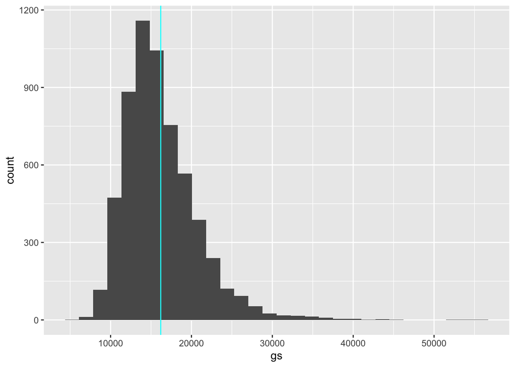

```r
# graph two most sensitive parameters
both = cbind.data.frame(parms, gs=sens_Catm_Sobol$y)

# look at overall gs sensitvity to uncertainty
ggplot(both, aes(x=gs))+geom_histogram()+geom_vline(xintercept=mean(both$gs), col="cyan")
```

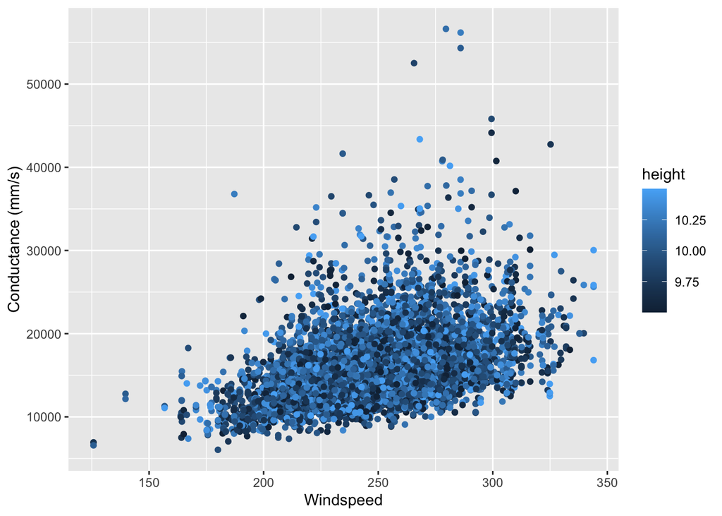

```r
# look at response of conductance to the two interesting variables
ggplot(both, aes(v,gs, col=height))+geom_point()+labs(y="Conductance (mm/s)", x="Windspeed")
```

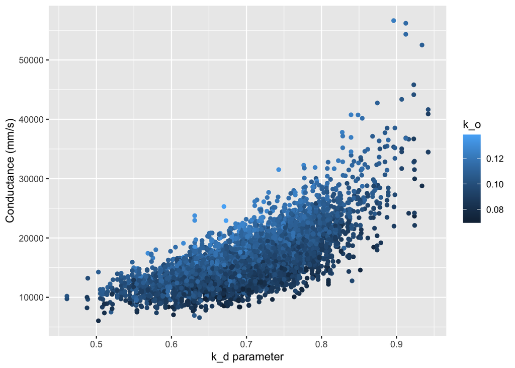

```r
# look at response of conductance to the two most important variables
ggplot(both, aes(k_d,gs, col=k_o))+geom_point()+labs(y="Conductance (mm/s)", x="k_d parameter")
```

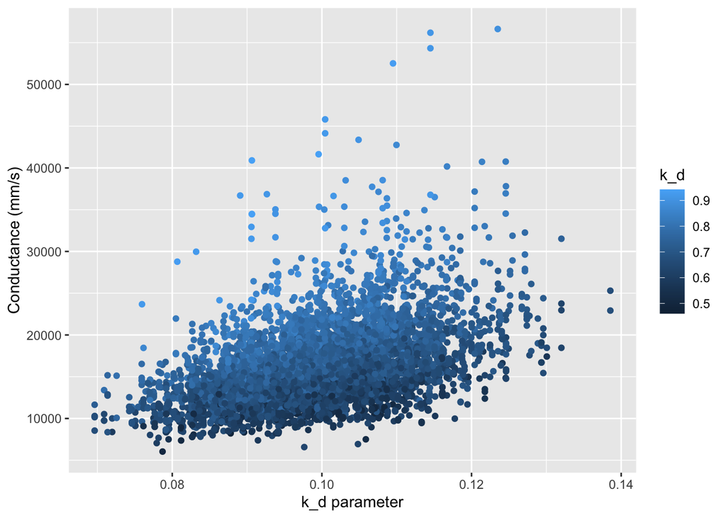

```r
# use second most sensitive parameter (using most important as color)
ggplot(both, aes(k_o,gs, col=k_d))+geom_point()+labs(y="Conductance (mm/s)", x="k_d parameter")
```

# Second order indices

Optional for this course

If you want to also compute a second order indices you need to use a different variation. (scheme=B)

There are multiple implementation of Sobol in the *senstivity* package, they can be more or less stable I find *sobolSalt* works well

```r
sens_Catm_Sobol2 = sobolSalt(model = NULL, X1, X2, nboot = 100, scheme="B" )

parms = as.data.frame(sens_Catm_Sobol2$X)
colnames(parms)= colnames(X1)
res = pmap_dbl(parms, Catm)


sens_Catm_Sobol2 = sensitivity::tell(sens_Catm_Sobol2,res, res.names="ga")

# main effect:  partitions variance (main effect without co-variance) - sums approximately to one
row.names(sens_Catm_Sobol2$S) = colnames(parms)
sens_Catm_Sobol2$S
```

```
##           original         bias std. error   min. c.i.  max. c.i.
## k_o    0.229944542  0.003265102 0.02628059  0.16591349 0.27518625
## k_d    0.539938389 -0.003062921 0.02090812  0.50977451 0.58425355
## height 0.008747962  0.003317912 0.02824280 -0.06696647 0.05946964
```

```r
# total effect - accounts for parameter interactions
row.names(sens_Catm_Sobol2$T) = colnames(parms)
sens_Catm_Sobol2$T
```

```
##           original          bias   std. error   min. c.i.   max. c.i.
## k_o    0.250817430  9.190749e-04 0.0139204932 0.222237895 0.277504474
## k_d    0.580451614 -3.258796e-03 0.0271275120 0.542007540 0.648047832
## height 0.004340003  6.486209e-05 0.0003016948 0.003514678 0.004849535
```

```r
# second order parameters interaction in controlling sensitivity
# parameters are in order, interactiosn are small here
sens_Catm_Sobol2$S2
```

```
##          original          bias std. error   min. c.i.  max. c.i.
## X1X2  0.027785596 -0.0014529220 0.02829157 -0.02686913 0.09962181
## X1X3 -0.002819544 -0.0050953180 0.03255389 -0.06120048 0.07227381
## X1X4 -0.002944231 -0.0033108960 0.02856459 -0.05435563 0.07336326
## X2X3  0.024202493 -0.0009961093 0.03035267 -0.03674768 0.09206216
## X2X4 -0.000666814 -0.0033026313 0.02793842 -0.05208426 0.07428829
## X3X4 -0.002903990 -0.0032506781 0.02853356 -0.05681996 0.07196193
```